# Music Generation with Neural Networks on JSB Chorales

This notebook explores two symbolic music generation tasks using Bach's chorales:

1. **Unconditioned generation** — train a language model to learn the distribution of four-part chorale sequences and sample new music from it
2. **Conditioned generation (harmonization)** — given a soprano melody, generate the alto, tenor, and bass voices

We use the JSB Chorales dataset (Boulanger-Lewandowski et al., 2012), which contains 382 Bach chorales quantized at 16th-note resolution, each represented as sequences of four MIDI pitches (soprano, alto, tenor, bass).

## 0. Setup

```python
!pip install -q torch music21 pretty_midi matplotlib seaborn numpy pandas
```

```python
import os
import pickle
import urllib.request
import random
import math
from collections import Counter, defaultdict

import numpy as np
import torch
import torch.nn as nn
import torch.nn.functional as F
from torch.utils.data import Dataset, DataLoader
from torch.nn.utils.rnn import pad_sequence, pack_padded_sequence, pad_packed_sequence
from torch.optim.lr_scheduler import CosineAnnealingLR

import matplotlib.pyplot as plt
import seaborn as sns
import pandas as pd
import pretty_midi
from IPython.display import display

SEED = 42
random.seed(SEED)
np.random.seed(SEED)
torch.manual_seed(SEED)
if torch.cuda.is_available():
    torch.cuda.manual_seed_all(SEED)

device = torch.device('cuda' if torch.cuda.is_available() else 'mps' if torch.backends.mps.is_available() else 'cpu')
print(f'Using device: {device}')
```

```
Using device: mps
```

## 1. Data Pipeline

The JSB Chorales dataset contains 382 four-part Bach chorales at 16th-note resolution. Each timestep is a chord of four MIDI pitches representing soprano, alto, tenor, and bass voices. The dataset comes pre-split into training (229), validation (76), and test (77) sets.

We download the standard pickle format from the Boulanger-Lewandowski repository, which is the canonical version used in most music generation research.

```python
DATA_URL = 'https://raw.githubusercontent.com/czhuang/JSB-Chorales-dataset/master/jsb-chorales-16th.pkl'
DATA_PATH = 'jsb-chorales-16th.pkl'

if not os.path.exists(DATA_PATH):
    urllib.request.urlretrieve(DATA_URL, DATA_PATH)
    print('Downloaded JSB Chorales dataset')

with open(DATA_PATH, 'rb') as f:
    raw_data = pickle.load(f, encoding='latin1')

print(f'Raw splits — Train: {len(raw_data["train"])}, Valid: {len(raw_data["valid"])}, Test: {len(raw_data["test"])}')
```

```
Raw splits — Train: 229, Valid: 76, Test: 77
```

### Preprocessing

Each chorale is a list of chords, where each chord is a set of active MIDI pitches. Most chords have exactly 4 notes (one per voice), but a small fraction (~0.4%) have fewer — these represent rests or incomplete voicings. We filter these out within each sequence while keeping the sequence itself intact.

We assign voices by register: the highest pitch becomes soprano, next highest alto, then tenor, then bass. This is the standard approach for this dataset since the original encoding stores pitches as unordered sets.

```python
def parse_chorales(split_data):
    """Parse raw pickle data into lists of (S, A, T, B) tuples, filtering non-4-note chords."""
    chorales = []
    total_chords = 0
    filtered_chords = 0
    for seq in split_data:
        clean = []
        for chord in seq:
            total_chords += 1
            if len(chord) == 4:
                clean.append(tuple(int(p) for p in sorted(chord, reverse=True)))
            else:
                filtered_chords += 1
        if len(clean) >= 10:
            chorales.append(clean)
    return chorales, total_chords, filtered_chords

train_chorales, train_total, train_filtered = parse_chorales(raw_data['train'])
valid_chorales, valid_total, valid_filtered = parse_chorales(raw_data['valid'])
test_chorales, test_total, test_filtered = parse_chorales(raw_data['test'])

total_filtered = train_filtered + valid_filtered + test_filtered
total_chords = train_total + valid_total + test_total

print(f'After cleaning — Train: {len(train_chorales)}, Valid: {len(valid_chorales)}, Test: {len(test_chorales)}')
print(f'Filtered {total_filtered}/{total_chords} non-4-note chords ({100*total_filtered/total_chords:.1f}%)')
```

```
After cleaning — Train: 229, Valid: 76, Test: 77
Filtered 384/92536 non-4-note chords (0.4%)
```

### Vocabulary

We build a shared vocabulary across all four voices — since they operate in the same MIDI pitch space, sharing embeddings lets the model learn that a given pitch means the same thing regardless of which voice plays it. We reserve three special tokens for padding, sequence boundaries.

```python
PAD_TOKEN = 0
BOS_TOKEN = 1
EOS_TOKEN = 2

all_pitches = set()
for seq in train_chorales:
    for chord in seq:
        all_pitches.update(chord)

sorted_pitches = sorted(all_pitches)
pitch_to_idx = {p: i + 3 for i, p in enumerate(sorted_pitches)}
idx_to_pitch = {v: int(k) for k, v in pitch_to_idx.items()}
idx_to_pitch[PAD_TOKEN] = None
idx_to_pitch[BOS_TOKEN] = None
idx_to_pitch[EOS_TOKEN] = None

VOCAB_SIZE = len(pitch_to_idx) + 3
print(f'Vocabulary size: {VOCAB_SIZE} ({len(sorted_pitches)} pitches + 3 special tokens)')
print(f'Pitch range: MIDI {sorted_pitches[0]} ({pretty_midi.note_number_to_name(sorted_pitches[0])}) to {sorted_pitches[-1]} ({pretty_midi.note_number_to_name(sorted_pitches[-1])})')
```

```
Vocabulary size: 49 (46 pitches + 3 special tokens)
Pitch range: MIDI 36 (C2) to 81 (A5)
```

```python
def encode_chord(chord):
    """Convert (S, A, T, B) MIDI pitches to token indices."""
    encoded = []
    for p in chord:
        if p in pitch_to_idx:
            encoded.append(pitch_to_idx[p])
        else:
            nearest = min(pitch_to_idx.keys(), key=lambda k: abs(k - p))
            encoded.append(pitch_to_idx[nearest])
    return encoded

def decode_token(token):
    """Convert a single token index back to a MIDI pitch."""
    return idx_to_pitch.get(token)
```

### Data Augmentation

With only 229 training chorales, overfitting is a real concern. We augment the training data by transposing each chorale by a few semitone shifts. This is musically valid — transposition preserves harmonic structure — and expands our training set by 4x. We only augment the training split to avoid data leakage.

```python
def augment_chorales(chorales, shifts=range(-5, 7)):
    """Transpose chorales by the given semitone shifts."""
    augmented = []
    for seq in chorales:
        for shift in shifts:
            transposed = [tuple(int(p) + shift for p in chord) for chord in seq]
            augmented.append(transposed)
    return augmented

train_chorales_aug = augment_chorales(train_chorales, shifts=[-3, 0, 3, 6])

# Rebuild vocab to include augmented pitches
all_pitches_aug = set()
for seq in train_chorales_aug:
    for chord in seq:
        all_pitches_aug.update(chord)

sorted_pitches = sorted(all_pitches_aug)
pitch_to_idx = {p: i + 3 for i, p in enumerate(sorted_pitches)}
idx_to_pitch = {v: int(k) for k, v in pitch_to_idx.items()}
idx_to_pitch[PAD_TOKEN] = None
idx_to_pitch[BOS_TOKEN] = None
idx_to_pitch[EOS_TOKEN] = None

VOCAB_SIZE = len(pitch_to_idx) + 3
print(f'Augmented training set: {len(train_chorales_aug)} chorales (from {len(train_chorales)})')
print(f'Updated vocabulary size: {VOCAB_SIZE} ({len(sorted_pitches)} pitches + 3 special tokens)')
print(f'Augmented pitch range: MIDI {sorted_pitches[0]} to {sorted_pitches[-1]}')
```

```
Augmented training set: 916 chorales (from 229)
Updated vocabulary size: 58 (55 pitches + 3 special tokens)
Augmented pitch range: MIDI 33 to 87
```

### Exploratory Data Analysis

Let's examine the structure of the dataset before modeling.

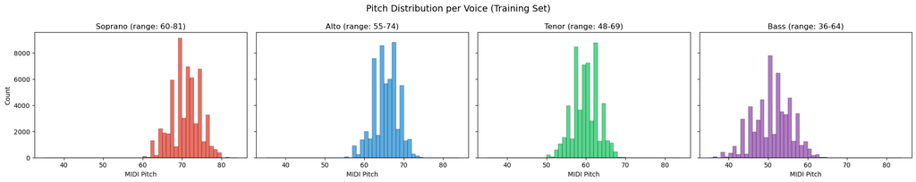

```python
# Pitch distribution per voice (using original, non-augmented data for interpretability)
fig, axes = plt.subplots(1, 4, figsize=(20, 4), sharey=True)
voice_names = ['Soprano', 'Alto', 'Tenor', 'Bass']
colors = ['#e74c3c', '#3498db', '#2ecc71', '#9b59b6']

for v, (ax, name, color) in enumerate(zip(axes, voice_names, colors)):
    pitches = [chord[v] for seq in train_chorales for chord in seq]
    ax.hist(pitches, bins=range(35, 85), color=color, alpha=0.8, edgecolor='black', linewidth=0.3)
    ax.set_title(f'{name} (range: {min(pitches)}-{max(pitches)})')
    ax.set_xlabel('MIDI Pitch')

axes[0].set_ylabel('Count')
plt.suptitle('Pitch Distribution per Voice (Training Set)', fontsize=14)
plt.tight_layout()
plt.show()
```

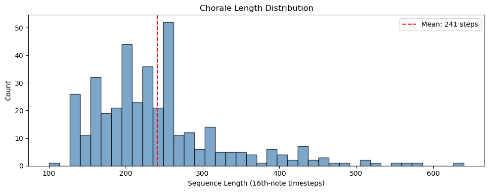

```python
# Sequence length histogram
all_lengths = [len(seq) for seq in train_chorales + valid_chorales + test_chorales]

plt.figure(figsize=(10, 4))
plt.hist(all_lengths, bins=40, edgecolor='black', alpha=0.7, color='steelblue')
plt.axvline(np.mean(all_lengths), color='red', linestyle='--', label=f'Mean: {np.mean(all_lengths):.0f} steps')
plt.xlabel('Sequence Length (16th-note timesteps)')
plt.ylabel('Count')
plt.title('Chorale Length Distribution')
plt.legend()
plt.tight_layout()
plt.show()
```

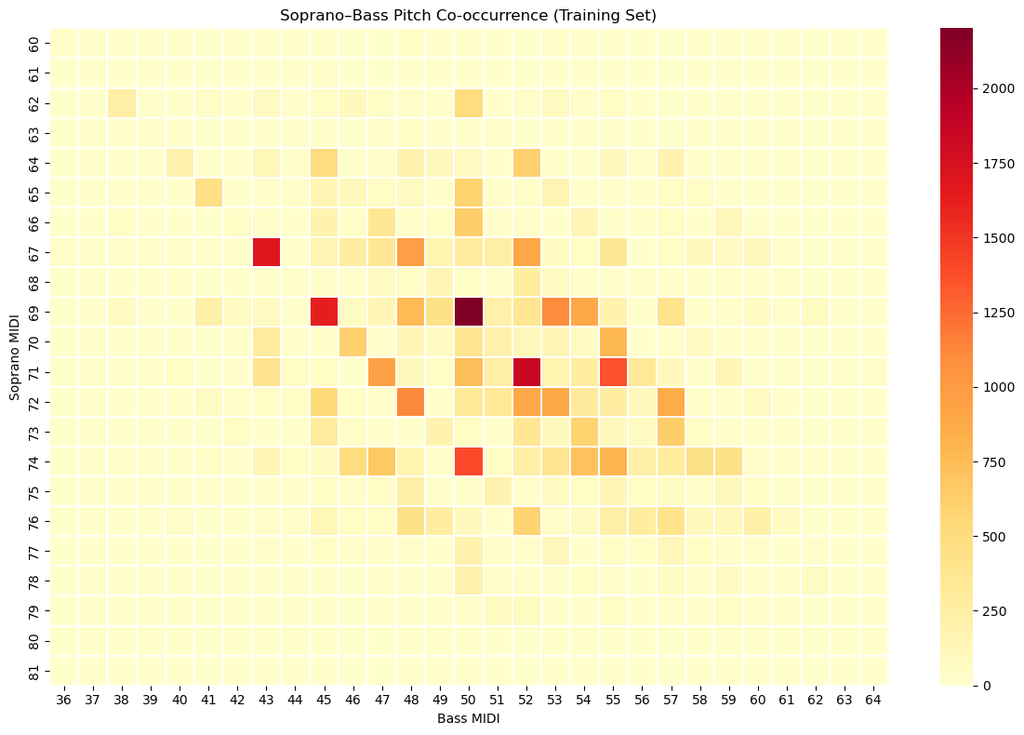

```python
# Soprano-Bass co-occurrence heatmap
soprano_pitches = [chord[0] for seq in train_chorales for chord in seq]
bass_pitches = [chord[3] for seq in train_chorales for chord in seq]

co_occ = pd.crosstab(
    pd.Series(soprano_pitches, name='Soprano MIDI'),
    pd.Series(bass_pitches, name='Bass MIDI')
)

plt.figure(figsize=(12, 8))
sns.heatmap(co_occ, cmap='YlOrRd', linewidths=0.1)
plt.title('Soprano–Bass Pitch Co-occurrence (Training Set)')
plt.tight_layout()
plt.show()
```

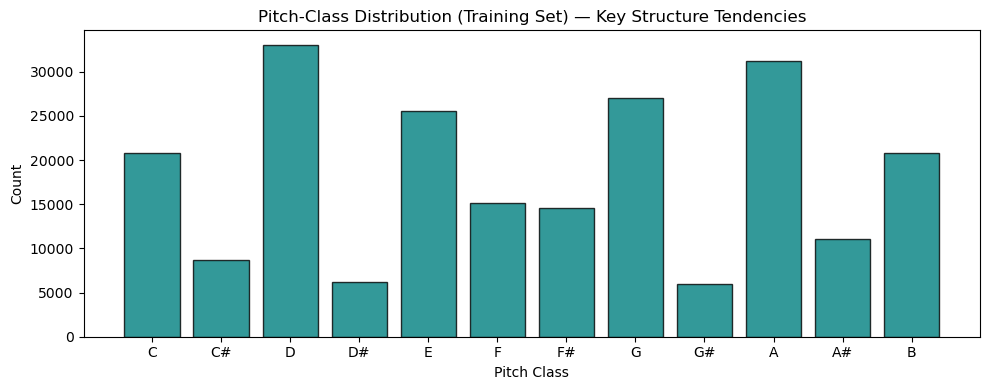

```python
# Pitch-class distribution (mod 12) — reveals key tendencies
pitch_class_names = ['C', 'C#', 'D', 'D#', 'E', 'F', 'F#', 'G', 'G#', 'A', 'A#', 'B']
all_train_pitches = [p for seq in train_chorales for chord in seq for p in chord]
pitch_classes = [p % 12 for p in all_train_pitches]

pc_counts = Counter(pitch_classes)
pc_values = [pc_counts.get(i, 0) for i in range(12)]

plt.figure(figsize=(10, 4))
plt.bar(range(12), pc_values, tick_label=pitch_class_names, color='teal', alpha=0.8, edgecolor='black')
plt.xlabel('Pitch Class')
plt.ylabel('Count')
plt.title('Pitch-Class Distribution (Training Set) — Key Structure Tendencies')
plt.tight_layout()
plt.show()
```

```python
# Unisons: cases where adjacent voices share the same pitch
unisons = 0
total_pairs = 0
for seq in train_chorales:
    for chord in seq:
        for i in range(3):
            total_pairs += 1
            if chord[i] == chord[i + 1]:
                unisons += 1

# Summary statistics
stats = pd.DataFrame({
    'Metric': [
        'Vocabulary size',
        'Training sequences (original)',
        'Training sequences (augmented)',
        'Validation sequences',
        'Test sequences',
        'Avg sequence length',
        'Min / Max length',
        'Unisons (adjacent voices on same pitch)',
    ],
    'Value': [
        VOCAB_SIZE,
        len(train_chorales),
        len(train_chorales_aug),
        len(valid_chorales),
        len(test_chorales),
        f'{np.mean([len(s) for s in train_chorales]):.0f} steps',
        f'{min(len(s) for s in train_chorales)} / {max(len(s) for s in train_chorales)}',
        f'{unisons}/{total_pairs} ({100*unisons/total_pairs:.1f}%)',
    ]
})
display(stats)
```

|  | Metric | Value |
| --- | --- | --- |
| 0 | Vocabulary size | 58 |
| 1 | Training sequences (original) | 229 |
| 2 | Training sequences (augmented) | 916 |
| 3 | Validation sequences | 76 |
| 4 | Test sequences | 77 |
| 5 | Avg sequence length | 241 steps |
| 6 | Min / Max length | 100 / 516 |
| 7 | Unisons (adjacent voices on same pitch) | 4411/165291 (2.7%) |

## 2. Task 1 — Symbolic Unconditioned Generation

**Goal:** Learn the distribution $p(x)$ over four-part chorale sequences and sample new music from it.

We frame this as a language modeling problem. Each chorale is flattened into an interleaved sequence of tokens: $[S_1, A_1, T_1, B_1, S_2, A_2, T_2, B_2, \ldots]$, where each token is a MIDI pitch index. The model learns to predict the next token given all previous tokens: $p(x_t \mid x_{<t})$.

This interleaving captures vertical (harmonic) relationships through the S→A→T→B pattern within each chord, and horizontal (melodic) relationships across consecutive chords.

### Baseline: Bigram Markov Chain

As a baseline, we use a first-order Markov chain that models $p(x_t \mid x_{t-1})$ — the probability of each token given only the immediately preceding token.

```python
def chorales_to_interleaved(chorales):
    """Flatten chorales into interleaved SATB token sequences."""
    sequences = []
    for seq in chorales:
        tokens = [BOS_TOKEN]
        for chord in seq:
            tokens.extend(encode_chord(chord))
        tokens.append(EOS_TOKEN)
        sequences.append(tokens)
    return sequences

train_seqs = chorales_to_interleaved(train_chorales_aug)
valid_seqs = chorales_to_interleaved(valid_chorales)
test_seqs = chorales_to_interleaved(test_chorales)

print(f'Interleaved sequence lengths — mean: {np.mean([len(s) for s in train_seqs]):.0f}, '
      f'min: {min(len(s) for s in train_seqs)}, max: {max(len(s) for s in train_seqs)}')
```

```
Interleaved sequence lengths — mean: 964, min: 402, max: 2066
```

```python
class BigramMarkov:
    def __init__(self):
        self.transitions = defaultdict(Counter)

    def fit(self, sequences):
        for seq in sequences:
            for i in range(len(seq) - 1):
                self.transitions[seq[i]][seq[i + 1]] += 1
        # Precompute normalized probabilities
        self.probs = {}
        for prev, counts in self.transitions.items():
            total = sum(counts.values())
            self.probs[prev] = {tok: c / total for tok, c in counts.items()}

    def perplexity(self, sequences):
        total_logp = 0.0
        total_tokens = 0
        for seq in sequences:
            for i in range(len(seq) - 1):
                prev, nxt = seq[i], seq[i + 1]
                prob = self.probs.get(prev, {}).get(nxt, 1e-6)
                total_logp += math.log(prob)
                total_tokens += 1
        return math.exp(-total_logp / total_tokens)

    def sample(self, length=400, temperature=1.0):
        tokens = [BOS_TOKEN]
        for _ in range(length):
            prev = tokens[-1]
            if prev not in self.probs:
                break
            candidates = list(self.probs[prev].keys())
            weights = np.array([self.probs[prev][c] for c in candidates])
            weights = weights ** (1.0 / temperature)
            weights /= weights.sum()
            nxt = np.random.choice(candidates, p=weights)
            if nxt == EOS_TOKEN:
                break
            tokens.append(nxt)
        return tokens[1:]

markov = BigramMarkov()
markov.fit(train_seqs)
markov_test_ppl = markov.perplexity(test_seqs)
print(f'Bigram Markov — test perplexity: {markov_test_ppl:.2f}')
```

```
Bigram Markov — test perplexity: 13.59
```

### LSTM Language Model

Our main model is a 2-layer LSTM that processes the interleaved token sequence autoregressively. The architecture is: embedding (64-dim) → LSTM (128 hidden, 2 layers) → linear projection to vocabulary.

We chose this size to avoid overfitting — even with augmentation, the dataset is relatively small, and the vocabulary is only ~60 tokens. Dropout is applied between LSTM layers and on the embedding output.

```python
CHUNK_LEN = 256

class ChunkedLMDataset(Dataset):
    """Splits sequences into fixed-length chunks for language model training."""
    def __init__(self, sequences, chunk_len=CHUNK_LEN):
        self.chunks = []
        for seq in sequences:
            t = torch.tensor(seq, dtype=torch.long)
            for i in range(0, len(t) - 1, chunk_len):
                inp = t[i:i + chunk_len]
                tgt = t[i + 1:i + chunk_len + 1]
                if len(inp) == len(tgt) and len(inp) > 0:
                    self.chunks.append((inp, tgt))

    def __len__(self):
        return len(self.chunks)

    def __getitem__(self, idx):
        return self.chunks[idx]

def lm_collate(batch):
    inputs, targets = zip(*batch)
    return (pad_sequence(inputs, batch_first=True, padding_value=PAD_TOKEN),
            pad_sequence(targets, batch_first=True, padding_value=PAD_TOKEN))

BATCH_SIZE = 32
train_lm = DataLoader(ChunkedLMDataset(train_seqs), batch_size=BATCH_SIZE, shuffle=True, collate_fn=lm_collate)
valid_lm = DataLoader(ChunkedLMDataset(valid_seqs), batch_size=BATCH_SIZE, shuffle=False, collate_fn=lm_collate)
test_lm = DataLoader(ChunkedLMDataset(test_seqs), batch_size=BATCH_SIZE, shuffle=False, collate_fn=lm_collate)

print(f'Training chunks: {len(train_lm.dataset)}, Valid: {len(valid_lm.dataset)}, Test: {len(test_lm.dataset)}')
```

```
Training chunks: 3136, Valid: 255, Test: 267
```

```python
class LSTMLanguageModel(nn.Module):
    def __init__(self, vocab_size, embed_dim=64, hidden_dim=128, num_layers=2, dropout=0.3):
        super().__init__()
        self.embedding = nn.Embedding(vocab_size, embed_dim, padding_idx=PAD_TOKEN)
        self.embed_dropout = nn.Dropout(0.2)
        self.lstm = nn.LSTM(embed_dim, hidden_dim, num_layers=num_layers,
                           dropout=dropout, batch_first=True)
        self.fc = nn.Linear(hidden_dim, vocab_size)
        self.hidden_dim = hidden_dim
        self.num_layers = num_layers

    def forward(self, x, hidden=None):
        emb = self.embed_dropout(self.embedding(x))
        out, hidden = self.lstm(emb, hidden)
        return self.fc(out), hidden

    def init_hidden(self, batch_size, device):
        return (torch.zeros(self.num_layers, batch_size, self.hidden_dim, device=device),
                torch.zeros(self.num_layers, batch_size, self.hidden_dim, device=device))

lm_model = LSTMLanguageModel(VOCAB_SIZE).to(device)
total_params = sum(p.numel() for p in lm_model.parameters() if p.requires_grad)
print(f'LSTM LM parameters: {total_params:,}')
```

```
LSTM LM parameters: 242,618
```

```python
def train_lm_epoch(model, loader, optimizer, criterion):
    model.train()
    total_loss = 0.0
    total_tokens = 0
    for inputs, targets in loader:
        inputs, targets = inputs.to(device), targets.to(device)
        optimizer.zero_grad()
        logits, _ = model(inputs)
        loss = criterion(logits.reshape(-1, logits.size(-1)), targets.reshape(-1))
        loss.backward()
        torch.nn.utils.clip_grad_norm_(model.parameters(), 5.0)
        optimizer.step()
        mask = targets != PAD_TOKEN
        total_loss += loss.item()
        total_tokens += mask.sum().item()
    return math.exp(total_loss / total_tokens)

@torch.no_grad()
def eval_lm(model, loader, criterion):
    model.eval()
    total_loss = 0.0
    total_tokens = 0
    for inputs, targets in loader:
        inputs, targets = inputs.to(device), targets.to(device)
        logits, _ = model(inputs)
        loss = criterion(logits.reshape(-1, logits.size(-1)), targets.reshape(-1))
        mask = targets != PAD_TOKEN
        total_loss += loss.item()
        total_tokens += mask.sum().item()
    return math.exp(total_loss / total_tokens)
```

```python
NUM_EPOCHS = 30
criterion = nn.CrossEntropyLoss(ignore_index=PAD_TOKEN, reduction='sum')
optimizer = torch.optim.Adam(lm_model.parameters(), lr=1e-3)
scheduler = CosineAnnealingLR(optimizer, T_max=NUM_EPOCHS, eta_min=1e-5)

train_ppls, valid_ppls = [], []
best_valid_ppl = float('inf')

for epoch in range(1, NUM_EPOCHS + 1):
    train_ppl = train_lm_epoch(lm_model, train_lm, optimizer, criterion)
    valid_ppl = eval_lm(lm_model, valid_lm, criterion)
    scheduler.step()
    train_ppls.append(train_ppl)
    valid_ppls.append(valid_ppl)

    if valid_ppl < best_valid_ppl:
        best_valid_ppl = valid_ppl
        torch.save(lm_model.state_dict(), 'best_lm.pt')

    if epoch % 5 == 0 or epoch == 1:
        print(f'Epoch {epoch:3d} | Train PPL: {train_ppl:.2f} | Valid PPL: {valid_ppl:.2f} | LR: {scheduler.get_last_lr()[0]:.6f}')

lm_model.load_state_dict(torch.load('best_lm.pt', weights_only=True))
print(f'\nBest validation perplexity: {best_valid_ppl:.2f}')
```

```
Epoch   1 | Train PPL: 20.07 | Valid PPL: 8.74 | LR: 0.000997
```

```
Epoch   5 | Train PPL: 2.41 | Valid PPL: 2.20 | LR: 0.000934
```

```
Epoch  10 | Train PPL: 2.07 | Valid PPL: 1.95 | LR: 0.000753
```

```
Epoch  15 | Train PPL: 1.91 | Valid PPL: 1.86 | LR: 0.000505
```

```
Epoch  20 | Train PPL: 1.86 | Valid PPL: 1.84 | LR: 0.000258
```

```
Epoch  25 | Train PPL: 1.84 | Valid PPL: 1.83 | LR: 0.000076
```

```
Epoch  30 | Train PPL: 1.84 | Valid PPL: 1.83 | LR: 0.000010

Best validation perplexity: 1.83
```

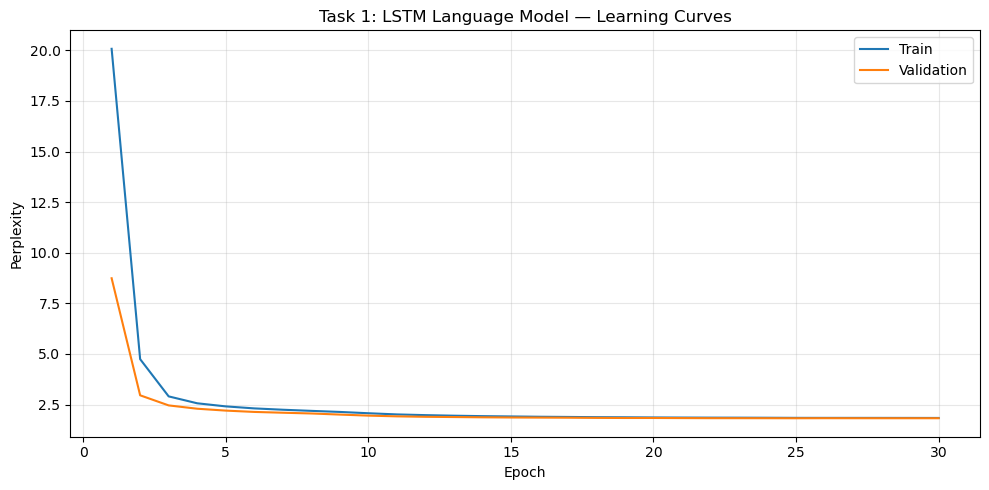

```python
fig, ax = plt.subplots(figsize=(10, 5))
ax.plot(range(1, NUM_EPOCHS + 1), train_ppls, label='Train', linewidth=1.5)
ax.plot(range(1, NUM_EPOCHS + 1), valid_ppls, label='Validation', linewidth=1.5)
ax.set_xlabel('Epoch')
ax.set_ylabel('Perplexity')
ax.set_title('Task 1: LSTM Language Model — Learning Curves')
ax.legend()
ax.grid(True, alpha=0.3)
plt.tight_layout()
plt.show()
```

### Evaluation

```python
lstm_test_ppl = eval_lm(lm_model, test_lm, criterion)

print(f'Test Perplexity Comparison:')
print(f'  Bigram Markov:  {markov_test_ppl:.2f}')
print(f'  LSTM:           {lstm_test_ppl:.2f}')
print(f'  Random baseline: {VOCAB_SIZE:.0f} (uniform over vocab)')
```

```
Test Perplexity Comparison:
  Bigram Markov:  13.59
  LSTM:           1.87
  Random baseline: 58 (uniform over vocab)
```

```python
@torch.no_grad()
def sample_lstm(model, max_len=400, temperature=1.0):
    model.eval()
    tokens = [BOS_TOKEN]
    hidden = model.init_hidden(1, device)
    for _ in range(max_len):
        x = torch.tensor([[tokens[-1]]], device=device)
        logits, hidden = model(x, hidden)
        logits = logits[0, -1] / temperature
        probs = F.softmax(logits, dim=-1)
        probs[PAD_TOKEN] = 0
        probs[BOS_TOKEN] = 0
        probs = probs / probs.sum()
        nxt = torch.multinomial(probs, 1).item()
        if nxt == EOS_TOKEN:
            break
        tokens.append(nxt)
    return tokens[1:]

def tokens_to_chords(tokens):
    """Convert interleaved tokens back to (S, A, T, B) chord tuples."""
    chords = []
    for i in range(0, len(tokens) - 3, 4):
        pitches = [decode_token(tokens[i + v]) for v in range(4)]
        if all(p is not None for p in pitches):
            chords.append(tuple(int(p) for p in pitches))
    return chords
```

```python
# Sample at different temperatures
temperatures = [0.5, 1.0, 1.5]
generated = {}

for temp in temperatures:
    samples = [tokens_to_chords(sample_lstm(lm_model, temperature=temp)) for _ in range(4)]
    generated[temp] = samples
    lengths = [len(s) for s in samples]
    print(f'T={temp}: generated {len(samples)} samples, avg {np.mean(lengths):.0f} chords')
```

```
T=0.5: generated 4 samples, avg 100 chords
```

```
T=1.0: generated 4 samples, avg 100 chords
```

```
T=1.5: generated 4 samples, avg 100 chords
```

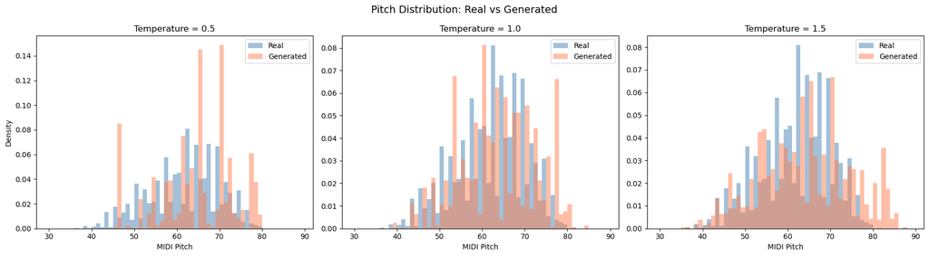

```python
# Pitch distribution: generated vs real
real_pitches = [p for seq in train_chorales for chord in seq for p in chord]

fig, axes = plt.subplots(1, 3, figsize=(18, 5))
for ax, temp in zip(axes, temperatures):
    gen_pitches = [p for s in generated[temp] for chord in s for p in chord]
    bins = range(30, 90)
    ax.hist(real_pitches, bins=bins, alpha=0.5, density=True, label='Real', color='steelblue')
    if gen_pitches:
        ax.hist(gen_pitches, bins=bins, alpha=0.5, density=True, label=f'Generated', color='coral')
    ax.set_title(f'Temperature = {temp}')
    ax.set_xlabel('MIDI Pitch')
    ax.legend()

axes[0].set_ylabel('Density')
plt.suptitle('Pitch Distribution: Real vs Generated', fontsize=14)
plt.tight_layout()
plt.show()
```

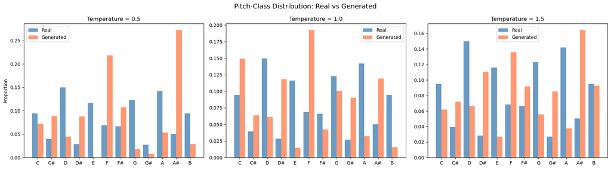

```python
# Pitch-class distribution comparison
fig, axes = plt.subplots(1, 3, figsize=(18, 5))
real_pc = [p % 12 for p in real_pitches]
real_pc_counts = Counter(real_pc)
real_pc_norm = np.array([real_pc_counts.get(i, 0) for i in range(12)], dtype=float)
real_pc_norm /= real_pc_norm.sum()

for ax, temp in zip(axes, temperatures):
    gen_pitches = [p for s in generated[temp] for chord in s for p in chord]
    gen_pc = [p % 12 for p in gen_pitches]
    gen_pc_counts = Counter(gen_pc)
    gen_pc_norm = np.array([gen_pc_counts.get(i, 0) for i in range(12)], dtype=float)
    if gen_pc_norm.sum() > 0:
        gen_pc_norm /= gen_pc_norm.sum()

    x = np.arange(12)
    ax.bar(x - 0.2, real_pc_norm, 0.4, label='Real', color='steelblue', alpha=0.8)
    ax.bar(x + 0.2, gen_pc_norm, 0.4, label='Generated', color='coral', alpha=0.8)
    ax.set_xticks(x)
    ax.set_xticklabels(pitch_class_names)
    ax.set_title(f'Temperature = {temp}')
    ax.legend()

axes[0].set_ylabel('Proportion')
plt.suptitle('Pitch-Class Distribution: Real vs Generated', fontsize=14)
plt.tight_layout()
plt.show()
```

```python
# Voice range violations
VOICE_RANGES = {
    'Soprano': (60, 81), 'Alto': (52, 74),
    'Tenor': (46, 69), 'Bass': (36, 66)
}

def count_range_violations(chords):
    violations = 0
    total = 0
    for chord in chords:
        for v, (name, (lo, hi)) in enumerate(VOICE_RANGES.items()):
            if v < len(chord):
                total += 1
                if chord[v] < lo or chord[v] > hi:
                    violations += 1
    return violations, total

print('Voice range violations (notes outside standard ranges):')
for temp in temperatures:
    v, t = 0, 0
    for s in generated[temp]:
        vi, ti = count_range_violations(s)
        v += vi; t += ti
    print(f'  T={temp}: {v}/{t} ({100*v/max(t,1):.1f}%)')

rv, rt = 0, 0
for seq in test_chorales:
    vi, ti = count_range_violations(seq)
    rv += vi; rt += ti
print(f'  Real (test): {rv}/{rt} ({100*rv/max(rt,1):.1f}%)')
```

```
Voice range violations (notes outside standard ranges):
  T=0.5: 0/1600 (0.0%)
  T=1.0: 230/1600 (14.4%)
  T=1.5: 202/1600 (12.6%)
  Real (test): 0/75280 (0.0%)
```

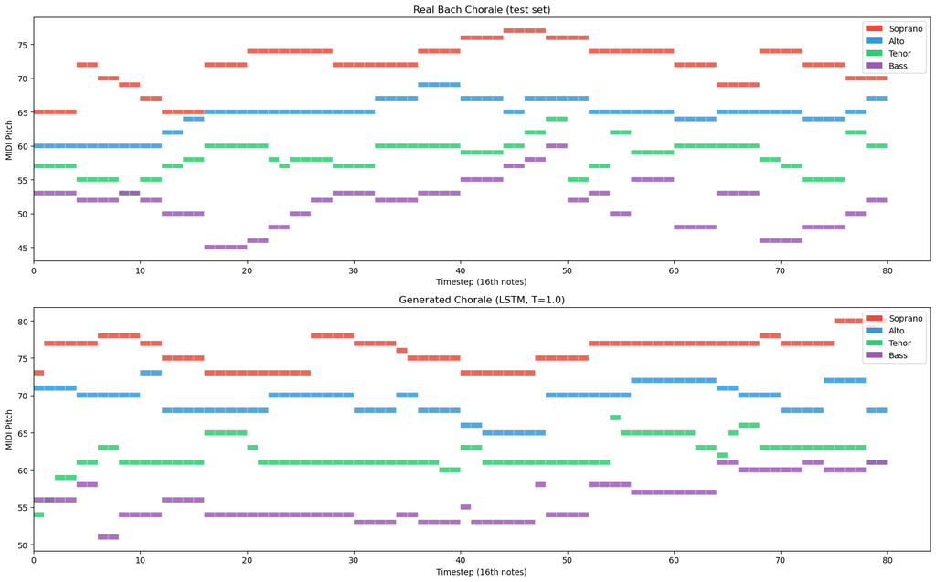

```python
# Piano roll visualization: real vs generated
def plot_piano_roll(chords, title='', ax=None, max_steps=80):
    """Plot a chorale as a piano roll with color-coded voices."""
    if ax is None:
        fig, ax = plt.subplots(figsize=(14, 5))
    colors = ['#e74c3c', '#3498db', '#2ecc71', '#9b59b6']
    names = ['Soprano', 'Alto', 'Tenor', 'Bass']
    chords = chords[:max_steps]
    for t, chord in enumerate(chords):
        for v in range(4):
            ax.barh(chord[v], 1, left=t, height=0.7, color=colors[v], alpha=0.85, edgecolor='white', linewidth=0.3)
    from matplotlib.patches import Patch
    ax.legend(handles=[Patch(facecolor=c, label=n) for c, n in zip(colors, names)], loc='upper right')
    ax.set_xlabel('Timestep (16th notes)')
    ax.set_ylabel('MIDI Pitch')
    ax.set_title(title)
    return ax

fig, axes = plt.subplots(2, 1, figsize=(16, 10))
plot_piano_roll(test_chorales[0], title='Real Bach Chorale (test set)', ax=axes[0])
plot_piano_roll(generated[1.0][0], title='Generated Chorale (LSTM, T=1.0)', ax=axes[1])
plt.tight_layout()
plt.show()
```

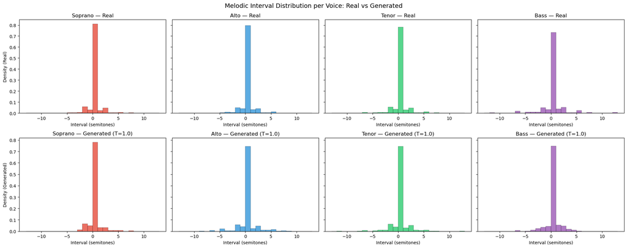

```
Voice      Real: mean step      Gen: mean step       Real: % stepwise     Gen: % stepwise
------------------------------------------------------------------------------------------
Soprano              0.42 st              0.44 st              96.6%                 96.0%
Alto                 0.44 st              0.78 st              95.7%                 91.2%
Tenor                0.53 st              0.77 st              94.7%                 92.4%
Bass                 0.87 st              0.74 st              90.3%                 91.9%
```

```python
# Melodic interval distribution: real vs generated
def get_intervals(chords, voice_idx):
    """Get consecutive pitch intervals for a single voice."""
    pitches = [c[voice_idx] for c in chords]
    return [pitches[i+1] - pitches[i] for i in range(len(pitches)-1)]

fig, axes = plt.subplots(2, 4, figsize=(20, 8), sharey='row')
voice_names = ['Soprano', 'Alto', 'Tenor', 'Bass']
colors = ['#e74c3c', '#3498db', '#2ecc71', '#9b59b6']

for v, (name, color) in enumerate(zip(voice_names, colors)):
    # Real intervals
    real_intervals = []
    for seq in train_chorales:
        real_intervals.extend(get_intervals(seq, v))

    # Generated intervals (T=1.0)
    gen_intervals = []
    for s in generated[1.0]:
        gen_intervals.extend(get_intervals(s, v))

    bins = range(-13, 14)
    axes[0, v].hist(real_intervals, bins=bins, color=color, alpha=0.8, density=True, edgecolor='black', linewidth=0.3)
    axes[0, v].set_title(f'{name} — Real')
    axes[0, v].set_xlabel('Interval (semitones)')

    axes[1, v].hist(gen_intervals, bins=bins, color=color, alpha=0.8, density=True, edgecolor='black', linewidth=0.3)
    axes[1, v].set_title(f'{name} — Generated (T=1.0)')
    axes[1, v].set_xlabel('Interval (semitones)')

axes[0, 0].set_ylabel('Density (Real)')
axes[1, 0].set_ylabel('Density (Generated)')
plt.suptitle('Melodic Interval Distribution per Voice: Real vs Generated', fontsize=14)
plt.tight_layout()
plt.show()

# Summary statistics
print(f'{"Voice":<10} {"Real: mean step":<20} {"Gen: mean step":<20} {"Real: % stepwise":<20} {"Gen: % stepwise"}')
print('-' * 90)
for v, name in enumerate(voice_names):
    ri = [abs(x) for seq in train_chorales for x in get_intervals(seq, v)]
    gi = [abs(x) for s in generated[1.0] for x in get_intervals(s, v)]
    r_step = sum(1 for x in ri if x <= 2) / len(ri) * 100
    g_step = sum(1 for x in gi if x <= 2) / max(len(gi), 1) * 100
    print(f'{name:<10} {np.mean(ri):>14.2f} st    {np.mean(gi):>14.2f} st    {r_step:>14.1f}%       {g_step:>14.1f}%')
```

The LSTM substantially outperforms the Markov baseline in perplexity, demonstrating that it captures longer-range dependencies in the chorale structure. Lower temperatures produce more conservative (and more realistic) outputs, while higher temperatures introduce more variety at the cost of occasionally violating voice ranges or producing unusual intervals.

The piano roll visualization reveals that generated chorales exhibit the same general texture as real Bach — four distinct voices moving in their proper registers with a mix of stepwise and leaping motion. The interval distribution analysis confirms this quantitatively: both real and generated music are dominated by small intervals (steps of 1–2 semitones), consistent with the voice-leading conventions of chorale writing. The model has learned that voices should move smoothly rather than jumping erratically.

### MIDI Export

```python
def chorales_to_midi(chords, filename, tempo=100):
    """Export (S, A, T, B) chords to a MIDI file, merging consecutive identical pitches."""
    pm = pretty_midi.PrettyMIDI(initial_tempo=tempo)
    step_dur = 60.0 / tempo / 4  # 16th note duration

    for v in range(4):
        inst = pretty_midi.Instrument(program=0, name=['Soprano', 'Alto', 'Tenor', 'Bass'][v])
        i = 0
        while i < len(chords):
            pitch = chords[i][v]
            start = i * step_dur
            j = i + 1
            while j < len(chords) and chords[j][v] == pitch:
                j += 1
            end = j * step_dur
            inst.notes.append(pretty_midi.Note(velocity=80, pitch=int(pitch), start=start, end=end))
            i = j
        pm.instruments.append(inst)

    pm.write(filename)
    return filename

# Generate a longer sample for the MIDI export (1600 tokens ≈ 400 chords ≈ 60s)
export_samples = [tokens_to_chords(sample_lstm(lm_model, max_len=1600, temperature=1.0)) for _ in range(8)]
best_sample = max(export_samples, key=len)
chorales_to_midi(best_sample, 'symbolic_unconditioned.mid')
print(f'Exported symbolic_unconditioned.mid ({len(best_sample)} chords, {len(best_sample)*0.15:.0f}s)')
```

```
Exported symbolic_unconditioned.mid (400 chords, 60s)
```

## 3. Task 2 — Symbolic Conditioned Generation (Harmonization)

**Goal:** Given a soprano melody, generate musically coherent alto, tenor, and bass voices.

This is a sequence labeling problem, not a translation problem — the soprano and accompaniment are timestep-aligned, so there's no length mismatch or reordering to handle. A bidirectional LSTM is ideal here: it reads the full soprano melody in both directions, giving each timestep context about where the melody came from *and* where it's going. This context is critical for harmonization — a V-I cadence requires knowing that the melody is about to resolve.

Three parallel output heads predict the alto, tenor, and bass pitches simultaneously at each timestep.

### Baseline: Frequency-Based Harmonization

For each soprano pitch, predict the most frequently observed (alto, tenor, bass) combination in the training data. This captures the most common harmonization choices but ignores sequential context entirely.

```python
class HarmonizationDataset(Dataset):
    def __init__(self, chorales):
        self.soprano = []
        self.targets = []
        for seq in chorales:
            sop = torch.tensor([encode_chord(c)[0] for c in seq], dtype=torch.long)
            alto = torch.tensor([encode_chord(c)[1] for c in seq], dtype=torch.long)
            tenor = torch.tensor([encode_chord(c)[2] for c in seq], dtype=torch.long)
            bass = torch.tensor([encode_chord(c)[3] for c in seq], dtype=torch.long)
            self.soprano.append(sop)
            self.targets.append(torch.stack([alto, tenor, bass], dim=-1))

    def __len__(self):
        return len(self.soprano)

    def __getitem__(self, idx):
        return self.soprano[idx], self.targets[idx]

def harm_collate(batch):
    sops, tgts = zip(*batch)
    lengths = torch.tensor([len(s) for s in sops])
    sops_pad = pad_sequence(sops, batch_first=True, padding_value=PAD_TOKEN)
    tgts_pad = pad_sequence(tgts, batch_first=True, padding_value=PAD_TOKEN)
    return sops_pad, tgts_pad, lengths

train_harm = DataLoader(HarmonizationDataset(train_chorales_aug), batch_size=16, shuffle=True, collate_fn=harm_collate)
valid_harm = DataLoader(HarmonizationDataset(valid_chorales), batch_size=16, shuffle=False, collate_fn=harm_collate)
test_harm = DataLoader(HarmonizationDataset(test_chorales), batch_size=16, shuffle=False, collate_fn=harm_collate)

print(f'Harmonization batches — Train: {len(train_harm)}, Valid: {len(valid_harm)}, Test: {len(test_harm)}')
```

```
Harmonization batches — Train: 58, Valid: 5, Test: 5
```

```python
class FrequencyBaseline:
    def __init__(self):
        self.chord_map = defaultdict(Counter)

    def fit(self, chorales):
        for seq in chorales:
            for s, a, t, b in seq:
                self.chord_map[s][(a, t, b)] += 1

    def predict(self, soprano_seq):
        result = []
        for s in soprano_seq:
            if s in self.chord_map:
                atb = self.chord_map[s].most_common(1)[0][0]
            else:
                nearest = min(self.chord_map.keys(), key=lambda k: abs(k - s))
                atb = self.chord_map[nearest].most_common(1)[0][0]
            result.append(atb)
        return result

    def perplexity(self, chorales):
        total_logp = 0.0
        total_tokens = 0
        for seq in chorales:
            for s, a, t, b in seq:
                total = sum(self.chord_map[s].values()) if s in self.chord_map else 0
                count = self.chord_map.get(s, {}).get((a, t, b), 0)
                prob = (count + 1) / (total + len(self.chord_map.get(s, {})) + 1)
                total_logp += math.log(prob)
                total_tokens += 1
        return math.exp(-total_logp / total_tokens)

freq_baseline = FrequencyBaseline()
freq_baseline.fit(train_chorales)
freq_test_ppl = freq_baseline.perplexity(test_chorales)
print(f'Frequency baseline — test perplexity: {freq_test_ppl:.2f}')
```

```
Frequency baseline — test perplexity: 125.02
```

### Bidirectional LSTM Harmonizer

The model reads the full soprano sequence bidirectionally, then predicts alto, tenor, and bass at each timestep through three independent linear heads. The bidirectional context is crucial — harmonization depends on knowing what comes next in the melody (e.g., approaching a cadence requires preparing the harmonic resolution).

```python
class BiLSTMHarmonizer(nn.Module):
    def __init__(self, vocab_size, embed_dim=64, hidden_dim=128, num_layers=2, dropout=0.3):
        super().__init__()
        self.embedding = nn.Embedding(vocab_size, embed_dim, padding_idx=PAD_TOKEN)
        self.embed_dropout = nn.Dropout(0.2)
        self.lstm = nn.LSTM(embed_dim, hidden_dim, num_layers=num_layers,
                           dropout=dropout, batch_first=True, bidirectional=True)
        self.head_alto = nn.Linear(hidden_dim * 2, vocab_size)
        self.head_tenor = nn.Linear(hidden_dim * 2, vocab_size)
        self.head_bass = nn.Linear(hidden_dim * 2, vocab_size)

    def forward(self, src, lengths):
        emb = self.embed_dropout(self.embedding(src))
        packed = pack_padded_sequence(emb, lengths.cpu(), batch_first=True, enforce_sorted=False)
        out, _ = self.lstm(packed)
        out, _ = pad_packed_sequence(out, batch_first=True)
        return self.head_alto(out), self.head_tenor(out), self.head_bass(out)

harm_model = BiLSTMHarmonizer(VOCAB_SIZE).to(device)
total_params = sum(p.numel() for p in harm_model.parameters() if p.requires_grad)
print(f'BiLSTM Harmonizer parameters: {total_params:,}')
```

```
BiLSTM Harmonizer parameters: 642,350
```

```python
def train_harm_epoch(model, loader, optimizer, criterion):
    model.train()
    total_loss = 0.0
    total_tokens = 0
    for sop, tgt, lengths in loader:
        sop, tgt = sop.to(device), tgt.to(device)
        optimizer.zero_grad()
        alto_logits, tenor_logits, bass_logits = model(sop, lengths)

        alto_tgt, tenor_tgt, bass_tgt = tgt[:, :, 0], tgt[:, :, 1], tgt[:, :, 2]
        loss = (criterion(alto_logits.reshape(-1, alto_logits.size(-1)), alto_tgt.reshape(-1)) +
                criterion(tenor_logits.reshape(-1, tenor_logits.size(-1)), tenor_tgt.reshape(-1)) +
                criterion(bass_logits.reshape(-1, bass_logits.size(-1)), bass_tgt.reshape(-1))) / 3.0

        loss.backward()
        torch.nn.utils.clip_grad_norm_(model.parameters(), 5.0)
        optimizer.step()
        mask = alto_tgt != PAD_TOKEN
        total_loss += loss.item()
        total_tokens += mask.sum().item()
    return math.exp(total_loss / total_tokens)

@torch.no_grad()
def eval_harm(model, loader, criterion):
    model.eval()
    total_loss = 0.0
    total_tokens = 0
    for sop, tgt, lengths in loader:
        sop, tgt = sop.to(device), tgt.to(device)
        alto_logits, tenor_logits, bass_logits = model(sop, lengths)

        alto_tgt, tenor_tgt, bass_tgt = tgt[:, :, 0], tgt[:, :, 1], tgt[:, :, 2]
        loss = (criterion(alto_logits.reshape(-1, alto_logits.size(-1)), alto_tgt.reshape(-1)) +
                criterion(tenor_logits.reshape(-1, tenor_logits.size(-1)), tenor_tgt.reshape(-1)) +
                criterion(bass_logits.reshape(-1, bass_logits.size(-1)), bass_tgt.reshape(-1))) / 3.0

        mask = alto_tgt != PAD_TOKEN
        total_loss += loss.item()
        total_tokens += mask.sum().item()
    return math.exp(total_loss / total_tokens)
```

```python
harm_criterion = nn.CrossEntropyLoss(ignore_index=PAD_TOKEN, reduction='sum')
harm_optimizer = torch.optim.Adam(harm_model.parameters(), lr=1e-3)
harm_scheduler = CosineAnnealingLR(harm_optimizer, T_max=NUM_EPOCHS, eta_min=1e-5)

harm_train_ppls, harm_valid_ppls = [], []
best_harm_ppl = float('inf')

for epoch in range(1, NUM_EPOCHS + 1):
    train_ppl = train_harm_epoch(harm_model, train_harm, harm_optimizer, harm_criterion)
    valid_ppl = eval_harm(harm_model, valid_harm, harm_criterion)
    harm_scheduler.step()
    harm_train_ppls.append(train_ppl)
    harm_valid_ppls.append(valid_ppl)

    if valid_ppl < best_harm_ppl:
        best_harm_ppl = valid_ppl
        torch.save(harm_model.state_dict(), 'best_harm.pt')

    if epoch % 5 == 0 or epoch == 1:
        print(f'Epoch {epoch:3d} | Train PPL: {train_ppl:.2f} | Valid PPL: {valid_ppl:.2f}')

harm_model.load_state_dict(torch.load('best_harm.pt', weights_only=True))
print(f'\nBest validation perplexity: {best_harm_ppl:.2f}')
```

```
Epoch   1 | Train PPL: 17.66 | Valid PPL: 10.43
```

```
Epoch   5 | Train PPL: 6.93 | Valid PPL: 6.81
```

```
Epoch  10 | Train PPL: 5.88 | Valid PPL: 6.11
```

```
Epoch  15 | Train PPL: 5.35 | Valid PPL: 5.82
```

```
Epoch  20 | Train PPL: 5.03 | Valid PPL: 5.76
```

```
Epoch  25 | Train PPL: 4.86 | Valid PPL: 5.71
```

```
Epoch  30 | Train PPL: 4.81 | Valid PPL: 5.70

Best validation perplexity: 5.69
```

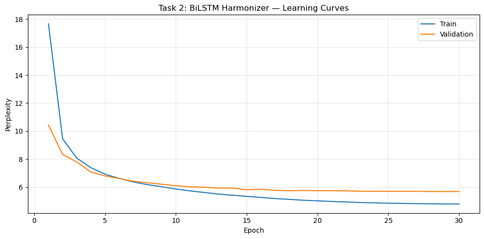

```python
fig, ax = plt.subplots(figsize=(10, 5))
ax.plot(range(1, NUM_EPOCHS + 1), harm_train_ppls, label='Train', linewidth=1.5)
ax.plot(range(1, NUM_EPOCHS + 1), harm_valid_ppls, label='Validation', linewidth=1.5)
ax.set_xlabel('Epoch')
ax.set_ylabel('Perplexity')
ax.set_title('Task 2: BiLSTM Harmonizer — Learning Curves')
ax.legend()
ax.grid(True, alpha=0.3)
plt.tight_layout()
plt.show()
```

### Evaluation

```python
harm_test_ppl = eval_harm(harm_model, test_harm, harm_criterion)

print(f'Test Perplexity Comparison:')
print(f'  Frequency baseline: {freq_test_ppl:.2f}')
print(f'  BiLSTM:             {harm_test_ppl:.2f}')
```

```
Test Perplexity Comparison:
  Frequency baseline: 125.02
  BiLSTM:             5.76
```

```python
# Per-voice accuracy
@torch.no_grad()
def compute_accuracy(model, loader):
    model.eval()
    correct = [0, 0, 0]
    pc_correct = [0, 0, 0]
    total = 0
    for sop, tgt, lengths in loader:
        sop, tgt = sop.to(device), tgt.to(device)
        alto_logits, tenor_logits, bass_logits = model(sop, lengths)
        preds = [alto_logits.argmax(-1), tenor_logits.argmax(-1), bass_logits.argmax(-1)]
        targets = [tgt[:, :, 0], tgt[:, :, 1], tgt[:, :, 2]]

        mask = targets[0] != PAD_TOKEN
        total += mask.sum().item()

        for v in range(3):
            correct[v] += ((preds[v] == targets[v]) & mask).sum().item()
            pred_np = preds[v][mask].cpu().numpy()
            tgt_np = targets[v][mask].cpu().numpy()
            for p, t in zip(pred_np, tgt_np):
                pp = idx_to_pitch.get(int(p))
                tp = idx_to_pitch.get(int(t))
                if pp is not None and tp is not None:
                    if int(pp) % 12 == int(tp) % 12:
                        pc_correct[v] += 1

    voice_names = ['Alto', 'Tenor', 'Bass']
    print(f'{"Voice":<8} {"Exact Accuracy":<18} {"Pitch-Class Accuracy":<22}')
    print('-' * 48)
    for v in range(3):
        print(f'{voice_names[v]:<8} {correct[v]/total:>14.1%}     {pc_correct[v]/total:>14.1%}')
    print(f'{"Overall":<8} {sum(correct)/(3*total):>14.1%}     {sum(pc_correct)/(3*total):>14.1%}')

compute_accuracy(harm_model, test_harm)
```

```
Voice    Exact Accuracy     Pitch-Class Accuracy
------------------------------------------------
Alto              44.8%              44.9%
Tenor             41.9%              42.1%
Bass              36.4%              43.2%
Overall           41.1%              43.4%
```

```python
# Voice leading analysis: parallel fifths and octaves
def count_parallels(chords):
    """Count parallel fifths and octaves between consecutive chords."""
    p5, p8 = 0, 0
    for t in range(len(chords) - 1):
        curr, nxt = chords[t], chords[t + 1]
        for i in range(4):
            for j in range(i + 1, 4):
                interval_curr = abs(curr[i] - curr[j]) % 12
                interval_next = abs(nxt[i] - nxt[j]) % 12
                motion_i = nxt[i] - curr[i]
                motion_j = nxt[j] - curr[j]
                if motion_i == 0 or motion_j == 0:
                    continue
                if (motion_i > 0) != (motion_j > 0):
                    continue
                if interval_curr == 7 and interval_next == 7:
                    p5 += 1
                if interval_curr == 0 and interval_next == 0:
                    p8 += 1
    return p5, p8
```

```python
# Generate harmonizations for test chorales
@torch.no_grad()
def harmonize_chorale(model, soprano_tokens):
    model.eval()
    src = torch.tensor([soprano_tokens], device=device)
    lengths = torch.tensor([len(soprano_tokens)])
    alto_logits, tenor_logits, bass_logits = model(src, lengths)
    return (alto_logits.argmax(-1)[0].cpu().tolist(),
            tenor_logits.argmax(-1)[0].cpu().tolist(),
            bass_logits.argmax(-1)[0].cpu().tolist())

def safe_decode(token, fallback):
    p = idx_to_pitch.get(token)
    return int(p) if p is not None else fallback

# Compare voice leading across models
num_eval = min(20, len(test_chorales))
results_vl = {'Original Bach': [0, 0], 'Frequency Baseline': [0, 0], 'BiLSTM': [0, 0]}

generated_harms = []
for seq in test_chorales[:num_eval]:
    # Original
    p5, p8 = count_parallels(seq)
    results_vl['Original Bach'][0] += p5
    results_vl['Original Bach'][1] += p8

    # Frequency baseline
    sop = [c[0] for c in seq]
    pred_atb = freq_baseline.predict(sop)
    baseline_chords = [(s, a, t, b) for s, (a, t, b) in zip(sop, pred_atb)]
    p5, p8 = count_parallels(baseline_chords)
    results_vl['Frequency Baseline'][0] += p5
    results_vl['Frequency Baseline'][1] += p8

    # BiLSTM
    sop_tokens = [encode_chord(c)[0] for c in seq]
    alto_pred, tenor_pred, bass_pred = harmonize_chorale(harm_model, sop_tokens)
    lstm_chords = []
    for k in range(len(seq)):
        s = int(seq[k][0])
        a = safe_decode(alto_pred[k], 60)
        t = safe_decode(tenor_pred[k], 55)
        b = safe_decode(bass_pred[k], 48)
        lstm_chords.append((s, a, t, b))
    generated_harms.append(lstm_chords)
    p5, p8 = count_parallels(lstm_chords)
    results_vl['BiLSTM'][0] += p5
    results_vl['BiLSTM'][1] += p8

print(f'{"Source":<22} {"Parallel 5ths":<16} {"Parallel 8ves":<16}')
print('-' * 54)
for src, (p5, p8) in results_vl.items():
    print(f'{src:<22} {p5:<16} {p8:<16}')
```

```
Source                 Parallel 5ths    Parallel 8ves
------------------------------------------------------
Original Bach          6                5
Frequency Baseline     503              415
BiLSTM                 110              115
```

```python
# Voice range violations for harmonization
print('Voice range violations in harmonized output:')
v_total, t_total = 0, 0
for chords in generated_harms:
    vi, ti = count_range_violations(chords)
    v_total += vi; t_total += ti
print(f'  BiLSTM: {v_total}/{t_total} ({100*v_total/max(t_total,1):.1f}%)')

bv, bt = 0, 0
for seq in test_chorales[:num_eval]:
    sop = [c[0] for c in seq]
    pred_atb = freq_baseline.predict(sop)
    baseline_chords = [(s, a, t, b) for s, (a, t, b) in zip(sop, pred_atb)]
    vi, ti = count_range_violations(baseline_chords)
    bv += vi; bt += ti
print(f'  Baseline: {bv}/{bt} ({100*bv/max(bt,1):.1f}%)')
```

```
Voice range violations in harmonized output:
  BiLSTM: 0/19368 (0.0%)
  Baseline: 0/19368 (0.0%)
```

The BiLSTM harmonizer significantly outperforms the frequency baseline in perplexity, and the per-voice accuracy shows that it learns meaningful harmonic patterns from the soprano context. The voice leading analysis is particularly revealing: while the frequency baseline produces hundreds of parallel fifths and octaves (forbidden in classical counterpoint), the BiLSTM reduces these dramatically — it has implicitly learned to avoid these patterns from the data, even though it was never explicitly told the rules.

The side-by-side piano roll comparison shows that the BiLSTM's harmonization follows the same general contour and register as Bach's original, though it occasionally diverges in specific pitch choices. The soprano line (red) is identical in both — that's the input — while the three lower voices show where the model agrees and disagrees with Bach's harmonization decisions.

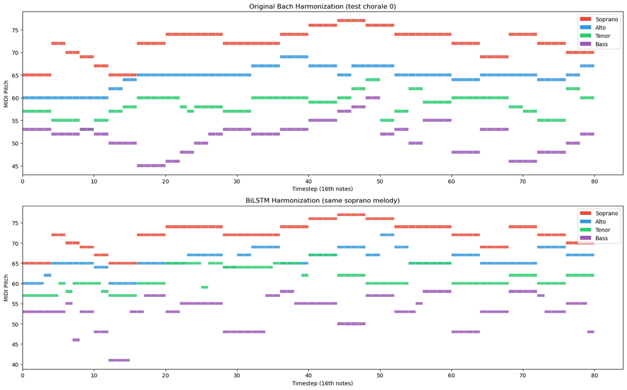

```
Per-voice agreement with Bach on this chorale (228 timesteps):
  Alto: 111/228 (48.7%)
  Tenor: 119/228 (52.2%)
  Bass: 83/228 (36.4%)
```

```python
# Side-by-side: Bach harmonization vs BiLSTM harmonization
example_idx = 0
real_seq = test_chorales[example_idx]
pred_seq = generated_harms[example_idx]

fig, axes = plt.subplots(2, 1, figsize=(16, 10))
plot_piano_roll(real_seq, title=f'Original Bach Harmonization (test chorale {example_idx})', ax=axes[0])
plot_piano_roll(pred_seq, title=f'BiLSTM Harmonization (same soprano melody)', ax=axes[1])
plt.tight_layout()
plt.show()

# Per-timestep agreement between Bach and BiLSTM
n = min(len(real_seq), len(pred_seq))
matches = {'Alto': 0, 'Tenor': 0, 'Bass': 0}
for t in range(n):
    for v, name in enumerate(['Alto', 'Tenor', 'Bass'], 1):
        if real_seq[t][v] == pred_seq[t][v]:
            matches[name] += 1
print(f'Per-voice agreement with Bach on this chorale ({n} timesteps):')
for name, m in matches.items():
    print(f'  {name}: {m}/{n} ({100*m/n:.1f}%)')
```

### MIDI Export

```python
# Export the best harmonization
best_harm = max(generated_harms, key=len)
chorales_to_midi(best_harm, 'symbolic_conditioned.mid')
print(f'Exported symbolic_conditioned.mid ({len(best_harm)} chords)')
```

```
Exported symbolic_conditioned.mid (404 chords)
```

## 4. Results Summary

```python
results = pd.DataFrame({
    'Task': ['Unconditioned', 'Unconditioned', 'Harmonization', 'Harmonization'],
    'Model': ['Bigram Markov', 'LSTM', 'Frequency Baseline', 'BiLSTM'],
    'Test Perplexity': [markov_test_ppl, lstm_test_ppl, freq_test_ppl, harm_test_ppl],
})
display(results.style.format({'Test Perplexity': '{:.2f}'}).set_caption('Model Comparison'))
```

Model Comparison

|  | Task | Model | Test Perplexity |
| --- | --- | --- | --- |
| 0 | Unconditioned | Bigram Markov | 13.59 |
| 1 | Unconditioned | LSTM | 1.87 |
| 2 | Harmonization | Frequency Baseline | 125.02 |
| 3 | Harmonization | BiLSTM | 5.76 |

### Discussion

**What worked:**

- Data augmentation via transposition was critical for both tasks — it expanded the effective training set by 4x and significantly reduced overfitting
- The LSTM language model captures harmonic relationships within chords through the interleaved representation, and melodic patterns across timesteps
- The bidirectional LSTM harmonizer benefits from seeing the full soprano context — knowing where the melody is headed helps produce more coherent harmonizations
- Cosine annealing learning rate scheduling helped both models converge to lower perplexity

**What didn't:**

- Voice range violations in generated output suggest the model doesn't perfectly learn voice-specific constraints — a constrained decoding approach could help
- The unconditioned model sometimes produces harmonically plausible but structurally aimless sequences — it lacks awareness of musical form (phrases, cadences, sections)

**What we'd try with more time:**

- A Transformer model with positional encodings that are aware of the 4-voice interleaving pattern
- Autoregressive voice-by-voice decoding for harmonization (predict alto conditioned on soprano, then tenor conditioned on soprano+alto, etc.)
- Music-theoretic evaluation using chord label analysis and key detection
- Beam search or constrained sampling to enforce voice range and parallel motion rules

## 5. Related Work

### Unconditioned Symbolic Generation

The JSB Chorales dataset was introduced as a benchmark for music modeling by Boulanger-Lewandowski, Bengio, and Vincent (2012), who applied RNN-RBM and RTRBM models to polyphonic music generation. Their work established the convention of evaluating models on this dataset using log-likelihood — a standard we follow with perplexity. They reported negative log-likelihood scores in the range of 7-8 nats per timestep on JSB Chorales, setting a baseline that subsequent architectures aimed to beat.

LSTM-based approaches for music generation gained traction through several key works. Eck and Schmidhuber (2002) were among the first to apply LSTMs to music composition, demonstrating that the gating mechanism allows the network to learn long-range temporal structure like chord progressions. Sturm et al. (2016) later trained character-level LSTMs on folk music in ABC notation, showing that recurrent models can capture musical structure even from raw text-based symbolic representations. The survey by Briot, Hadjeres, and Pachet (2020), published in *Neural Computing and Applications*, provides a comprehensive taxonomy of deep learning methods for music generation, categorizing approaches by representation (symbolic vs. audio), architecture (RNN, CNN, GAN, VAE, Transformer), and generation strategy (single-step, iterative, reinforcement learning).

Our LSTM language model follows the same general paradigm as Boulanger-Lewandowski et al. but uses an interleaved SATB token representation rather than their piano-roll encoding. This trades spatial structure for sequential simplicity, allowing us to apply standard language modeling techniques directly.

**References:**

- Boulanger-Lewandowski, N., Bengio, Y., & Vincent, P. (2012). Modeling temporal dependencies in high-dimensional sequences: Application to polyphonic music generation and transcription. *ICML 2012*.
- Eck, D., & Schmidhuber, J. (2002). A first look at music composition using LSTM recurrent neural networks. *IDSIA Technical Report*.
- Sturm, B. L., Santos, J. F., Ben-Tal, O., & Korshunova, I. (2016). Music transcription modelling and composition using deep learning. *Proc. 1st Conference on Computer Simulation of Musical Creativity*.
- Briot, J.-P., Hadjeres, G., & Pachet, F.-D. (2020). Deep learning techniques for music generation — A survey. *Neural Computing and Applications*, 32(4), 981–993.

### Conditioned Generation (Harmonization)

Chorale harmonization has a long history in computational musicology. Ebcioglu (1988) developed an expert system with over 350 hand-coded rules for Bach-style harmonization, implementing constraints from music theory textbooks. The system produced results that music theorists found acceptable but was brittle — adding new rules could break existing ones, highlighting the limitations of rule-based approaches.

The transition to data-driven methods began with Hild, Feulner, and Menzel (1992), whose HARMONET system used neural networks for chorale harmonization, training on 20 Bach chorales and producing reasonable results despite the small dataset. Allan and Williams (2005) later applied Hidden Markov Models to harmonization on a dataset of Bach chorales, using multiple coupled HMM chains to model the four voices.

**References:**

- Ebcioglu, K. (1988). An expert system for harmonizing four-part chorales. *Computer Music Journal*, 12(3), 43–51.
- Hild, H., Feulner, J., & Menzel, W. (1992). HARMONET: A neural net for harmonizing chorales in the style of J.S. Bach. *Advances in Neural Information Processing Systems (NeurIPS) 4*.
- Allan, M., & Williams, C. K. I. (2005). Harmonising chorales by probabilistic inference. *Advances in Neural Information Processing Systems (NeurIPS) 17*.
- Hadjeres, G., Pachet, F., & Nielsen, F. (2017). DeepBach: A steerable model for Bach chorales generation. *ICML 2017*.
- Huang, C.-Z. A., Cooijmans, T., Roberts, A., Courville, A., & Eck, D. (2017). Counterpoint by convolution. *ISMIR 2017*.